# Estimating oil-induced survival reduction

# Preamble

This is an Electronic Supplement to the manuscript Schwacke et al. 2022. Modeling population effects of the Deepwater Horizon oil spill on a long-lived species. $Conservation~Biology$ 36:e13878 DOI: https://doi.org/10.1111/cobi.13878

The master file containing links to all supplementary files related to this paper is BND_Electronic Supplements master file.

If you make use of any of this material in your work, it would be appreciated if you would contact Tiago Marques to let him know.

In case you are reading this document on git while browsing the material for the pelagic paper, the master file with supplementary material for the pelagic paper is here: Electronic Supplements master file.

# Background

In this document we describe the required analysis to estimate a baseline survival and the post-spill survival for common bottlenose dolphins in Barataria Bay (BB), which combined provide a survival reduction.

A fundamental aspect of the population dynamics model is that the animals exposed to oil are assumed to have a reduced survival rate.

The way we quantify that reduction in survival is by comparing a population-average baseline survival derived from the Siler model results previously reported by Schwacke et al. (2017) with a post-spill population-average survival obtained in a separate dedicated spatial capture recapture (SCR) model for photo-identification data collected during 2010-2019 surveys in BB (Glennie et al. 2021).

However, these two sources of information on survival reflect estimates for different components of the population. In particular, the SCR study reflects only a population-average survival that is not age- or sex- specific and that applies only to the fraction of the population that can be resighted, in other words, animals that have distinctive markings to be uniquely identified. Since animals are identified based on natural markings on dorsal fins, and young animals do not have such markings, younger animals are less likely to be included in the SCR study. Since we know from the Siler model that survival is sex and age dependent, this means that the population-average survival based on the SCR results alone would be biased, closer to a survival for older animals and ignoring the younger animal survival.

Here he describe in detail the post-processing required to transform the sex- and age- specific baseline survival estimates from the Siler model to a population-average survival compared to that of Glennie et al. 2021.

A note for clarity: it might seem surprising that we are transforming an (all other unknows assumed to not lead to bias) unbiased Siler-model based population-averaged estimate, to match a SCR-based biased towards older animals population-averaged survival estimate. However, the objective is to allow for a direct comparison between pre- and post-spill survivals. Since we do not have an unbiased population-averaged survival post-spill, this is the only way to do it.

# population-averaged baseline survival

To estimate a distribution for the baseline survival in bottlenose dolphins we consider the age and sex-specific survival from the Siler model results. Since we need a population-averaged survival rate, to obtain it we multiply the age- and sex-specific survival estimates from the Siler model by the proportion of the population estimated to be in each age- and sex- class.

As noted above, the baseline survival will be compared with survival post-spill that is calculated from a SCR model. The full SCR analysis is the focus of a dedicated SCR paper by Glennie et al. 2021. The SCR Photo-ID estimate of survival is a biased estimate of the population-average survival. In particular, young animals are not represented in the photo-ID catalog, as they tend to lack the markings that enable them to be uniquely identifiable. Hence, a first step is to use a separate dataset on whether animals are marked as a function of known age to estimate the proportion marked in each age class.

We note upfront this wording might cause some confusion. The **proportion marked** could be used to refer to:

1. the proportion of animals that have been marked in a MR context, and
2. the proportion of animals that could be marked in a photo-ID capture-recapture context because they have marks that make them uniquely identifiable.

Here, when we use the wording “proportion marked”, we are referring to the latter.

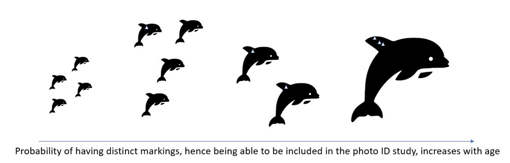

Based on this proportion marked, we calculate a baseline survival that can be compared with the SCR estimate by accounting for the proportion of animals, of each sex at each age, that could have been included in the SCR study.

Essentially, a population-averaged survival probability ($\bar S$) is given by

$$\bar S = \sum_{i=0}^{60}
\sum_{j=1}^2 s_{ij} \times q_{ij}$$

where

$$q_{ij} = \frac{p_{ij}\times
p(M|i)_{ij}}{\sum_{i=0}^{60} \sum_{j=1}^2 p_{ij}\times
p(M|i)_{ij}}$$

where $s_{ij}$ is the survival probability for age $i$ and sex $j$, $p_{ij}$ is the proportion of the population in age $i$ and sex $j$, $p(M|i)_{ij}$ is the proportion of animals of age $i$ and sex $j$ that are marked. Note therefore that $q_{ij}$ is the the proportion of animals marked in age $i$ and sex $j$.

Below we simulate each of these quantities, and propagate the corresponding uncertainty into $\bar S$ by sampling from the distribution of simulations for each of the components.

## Probability of being marked as a function of age

We consider a dataset containing known-age animals (from health assessments, etc.) from Barataria Bay (Lori Schwacke, unpublished data). We performed a binary logistic regression to estimate the probability of an animal being marked as a function of age and other covariates. Data were available for 54 dolphins in BB ranging in age from 2.5 to 42 years. For each of these animals there was a record of whether the animals had markings that would allow them to be marked by photo-ID, and hence being included in the pool of animals used to estimate survival from the SCR model.

The data is read in from file “BaselineSurvSIdata.txt”. Note that the original data had additional columns, with different characteristics associated with animals. However, we striped the file from anything that was not found to be relevant. As an example, the sex of the animal is not in the table, because we found no evidence for there to be sex-.related differences in the probability of an animal being marked as a function of age.

```r
#Read in data file
MRdata <- read.csv("InputFiles/BaselineSurvSIdata.txt", sep="")
```

Our objective is to model how the probability of an animal being marked (under column `Marked`, i.e. having been recruited into the capture-recapture (CR) study in Barataria Bay (BAR) from which we get baseline survival), as a function of potential covariates such as its age on capture `AgeCap`. These were fitted in R (R Core Team, 2021) with `gam` from R package `mgcv`.

Preliminary analysis showed that uncertainty was high at age 0, when we know probability of being marked is 0, so we considered a constrained GAM enforcing that the probability of being marked at age 0 is 0. Besides looking for sex differences, we also investigated imputing zero’s for all animals at age 0 to force the probability-of-being-marked-at-age-0-is-0 constraint, but the constrained GAM was favoured approach, hence the one that we present here below.

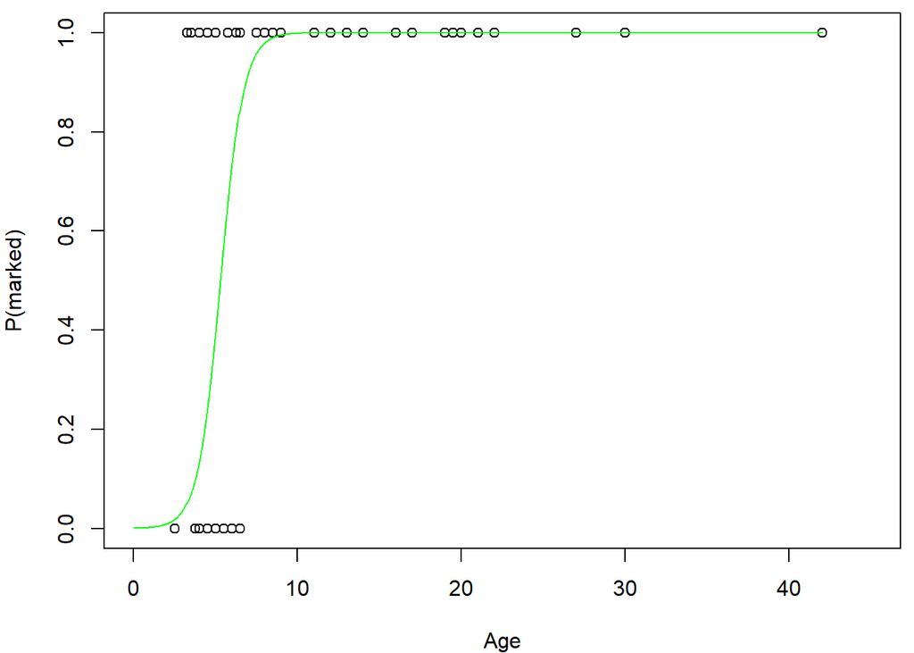

We present also the observed proportions of marked animals as a function of age as a goodness of fit assessment. The fit looks reasonable, except for the first bin, where we predict a lower proportion of marked animals than that observed. This is likely induced by the fact that the process of marking as a function of (young) age is not well approximated by the logistic link function. We move forward assuming that the impacts of this misfit would be negligible for our purposes, especially given all the uncertainty around this process.

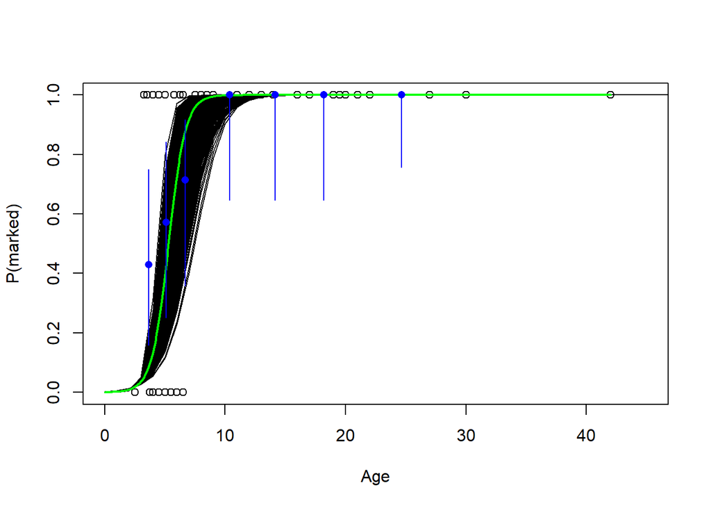

```r
AgeCap <- 0:60
newdata = data.frame(AgeCap = AgeCap)
sm2 <- smoothCon(s(AgeCap, k = n.knots, bs = "cr"), data = newdata, knots = knots)[[1]]
X2 <- sm2$X[, -1]
S2 <- sm2$S[[1]][-1, -1]
off.set2 <- rep(min.val, length = nrow(newdata))

set.seed(20932)
#Plot the data
with(MRdata,plot(Marked~AgeCap,xlim=c(0,45),ylab="P(marked)",xlab="Age"))
#Make predictions
Xp <- predict(gamAge.constr, newdata = list(AgeCap = newdata$AgeCap, X = X2, off.set = off.set2), type = "lpmatrix")
# define number of resamples
B <- 4000
br <- MASS::mvrnorm(B, coef(gamAge.constr), gamAge.constr$Vp)
res <- numeric(B)

predictions <- matrix(0, B, length(AgeCap))
for(i in 1:B){
  predictions[i, ] <- plogis(Xp %*% br[i, ] + min.val)[, 1]
  lines(AgeCap,predictions[i, ])
}
#Add in the original fit
ori.AgeCap <- seq(0, max(MRdata$AgeCap), length = 1000)
lines(ori.AgeCap, y.pred2, col = "green", lwd = 2)
#Divide data into n.dots equal portions by age and calculate proportion of marked for each portion
n.dots <- 7
ord <- order(MRdata$AgeCap)
ind <- rep(1:n.dots, each = length(ord)/n.dots)
if(length(ind) > length(ord)) ind <- ind[1:length(ord)]
ind <- c(ind, rep(n.dots, length(ord) - length(ind)))
mean.p <- by(MRdata$Marked[ord], ind, mean)
mean.age <- by(MRdata$AgeCap[ord], ind, mean)
mean.n <- by(MRdata$AgeCap[ord], ind, length)
points(mean.age, mean.p, pch = 16, col = "blue")
for(i in 1:length(mean.p)){
  conf <- Hmisc::binconf(mean.p[i] * mean.n[i], mean.n[i])
  lines(c(mean.age[i], mean.age[i]), conf[2:3], col = "blue")
}
```

In the above, the black lines are 4000 replicate predictions from the fit, the blue dots are the average proportion marked from the data grouped into 7 approximately equally sized bins and the blue vertical lines are 95% binomial confidence intervals on these proportions.

Below we represent the probability of being marked as a function of age and the corresponding pointwise percentile confidence intervals.

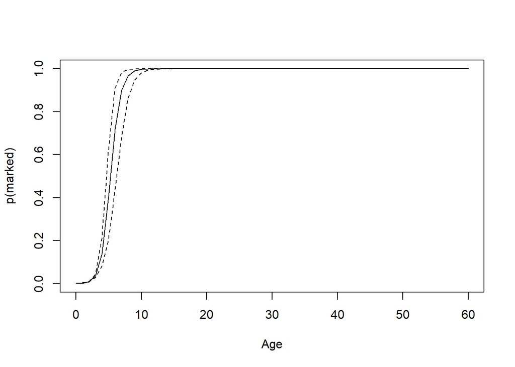

```r
#plot mean predictions, with confidence interval
plot(AgeCap, apply(predictions, 2, mean), type = "l", ylab = "p(marked)", xlab = "Age")
lines(AgeCap, apply(predictions, 2, quantile, 0.025),  lty = 2)
lines(AgeCap, apply(predictions, 2, quantile, 0.975),  lty = 2)
```

We output these vectors of probability of being marked as a function of age to be used later.

```r
# write results to use further, as/where needed
write.csv(predictions,"InputFiles/pmarked.csv",row.names = FALSE)
```

## Age and sex specific survival

The Siler model provides us the probability of survival as a function of age and sex. This is shown for the common botlenose dolphins below:

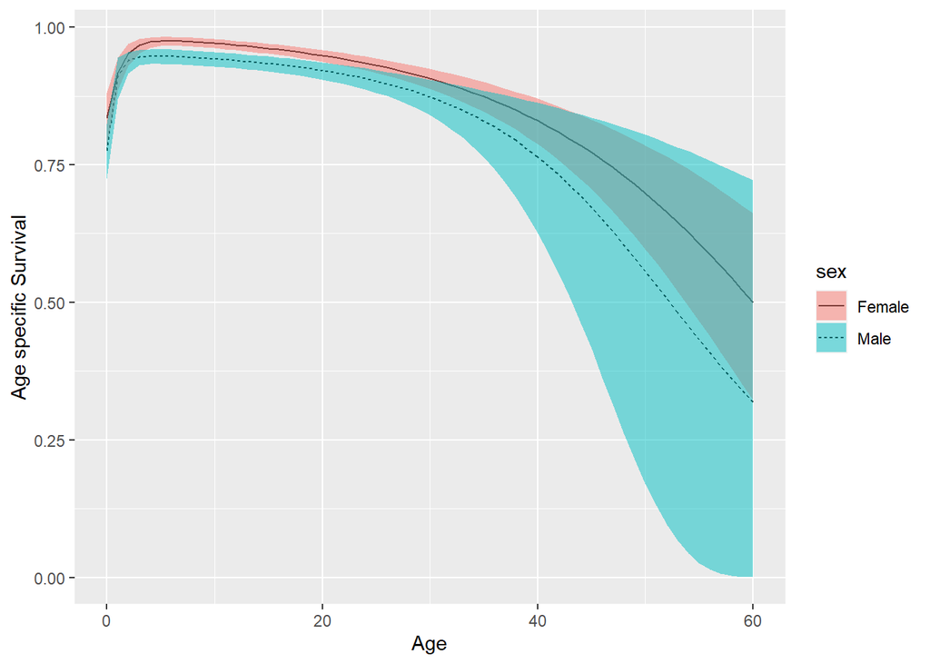

```r
#plot
#https://www.r-graph-gallery.com/104-plot-lines-with-error-envelopes-ggplot2.html
ggplot(data=pxMF, aes(x=ages, y=mean, ymin=q025, ymax=q975, fill=sex, linetype=sex)) + geom_line() +
 geom_ribbon(alpha=0.5) +
 xlab("Age") +
 ylab("Age specific Survival")
```

## Proportion of animals in each sex and age class

Given the Siler model, and the population model assumed, we can also can also estimate the baseline abundance per sex and age class.

The baseline proportion of animals in each sex and age class can be obtained by running essentially the same code that sets the baseline population of BND in the `runSims.R` function.

```r
# this code was taken out of "runSims.R" on the version file that was
# dated from the 26th January 2021. If that function is updated it might
# be sensible to check that this code is still the latest version

#--------------------------------------------------------------------------
Sp <- "Ttru"
set.seed(1234)
#--------------------------------------------------------------------------
# required libraries and functions
#--------------------------------------------------------------------------
# load required libraries
library(popbio)   #for computing mean age and expected time to live
library(mc2d)     # for beta-pert distribution
#--------------------------------------------------------------------------
source("Functions/reqfuns.R")         # most functions are here
#--------------------------------------------------------------------------
# Get all the relevant species information required to run the simulation
SpInfo <- getSpData(Sp)
#--------------------------------------------------------------------------
#--------------------------------------------------------------------------
# Set counters and constants
#--------------------------------------------------------------------------
  i       <- 1             # counter for the simulation iteration
  j       <- 1             # counter for the age class
  na      <- 61            # number of age classes for BND
  ns      <- 2             # number of sexes
  nc      <- 3             # number of conditions (see details above)
  dimm    <- ns * nc * na  # number of classes (2 sexes * 3 conditions * number of age classes)
  ages <- 0:(na-1)         # the ages considered
#------------------------------------------------------------
B<-4000
distNominais<-matrix(NA,nrow=B,ncol=2*na)
for(i in 1:B){
# Initial population size
Nstart <- read.csv(paste0("InOutBySp/",SpInfo$folder,"/N_boot.csv"), header = TRUE)
Nstart <- Nstart[,2]
Nstart<-as.vector(Nstart)
# Note: for smooth functioning "Nstart" and "survs" must have same length
# (currently 1000 values in each vector)
itersim <- sample(1:length(Nstart),1)
N0sim <- Nstart[itersim]
#--------------------------------------------------------------------------
# Survival
#--------------------------------------------------------------------------
# required information already read in above
#--------------------------------------------------------------------------
#------------------------------------------------------------

  # Survival
  femalesur <- px(ages, pf[i, 1], pf[i, 2], pf[i, 3], pf[i, 4], pf[i, 5])
  malesur   <- px(ages, pm[i, 1], pm[i, 2], pm[i, 3], pm[i, 4], pm[i, 5])
#------------------------------------------------------------
    # Fecundity
    # get DD fecundity parameters
    Fmaxsim <- with(SpInfo, rpert(1, min = minFmax, mode = modeFmax, max = maxFmax, shape = 4))
    Fnomsim <- with(SpInfo, rpert(1, min = minFnom, mode = modeFnom, max = maxFnom, shape = 4))
    rhosim  <- with(SpInfo, rhoshift+rgamma(1, shape = rhoshape, scale = rhoscale))
    # I need this to make sure don't hit problems with Fnom > Fmax which leads to NaNs!
    # but is this OK ?
    if(Fmaxsim < Fnomsim) Fnomsim <- Fmaxsim*0.99
    # note below we use the same N0sim twice
    # this is somewhat strange as it means that F0 becomes Fnomsim - but here anyway
    # Get baseline population fecundity - note this will only be used as such for BB BND
    # for all other taxonomic units we will change the IBI to reach a stable population
    F0 <- ft(Nt = N0sim, Fmax = Fmaxsim, rho  = rhosim, Nnom = N0sim, Fnom = Fnomsim)
    # obtain random deviate of age at first reproduction
    # this is for Tursiops, then scaled if other species
    # sample from right distribution
    a1stRsim <- with(SpInfo, rgamma(1, shape=sha1str, scale=sca1str))
    # the modeling requires an integer
    # and to adjust for possible scaling for non Ttru
    # the -0.5 is justified by a need to adjust the age of maturity to IBI - see emails
    # between LT, LS and TAM (thread ends Sun 6/21/2020 8:28 PM)
    a1stRsim <- round((a1stRsim-0.5))
    # and age at last reproduction - currently no senescent assumed, so commented out
    # alasRsim <- Ttru$alastRep
    # alasRsim <- round(alasRsim/scaling)
    # Baseline reproductive sucess rate
    # This is generated by using a beta with the mean value and variance equivalent
    # to the binomial corresponding to the same number of trials and successes
    # Baseline reproductive success rate
    # deprecated to use external data on survival to get these values directly
    # n <- SpInfo$n4brs
    # x <- SpInfo$suc4brs
    # p <- x/n
    # var.p <- p * (1 - p) / n
    # get parameters of binomial
    p <- SpInfo$meanbrs
    var.p <- SpInfo$sdbrs
    # transform to corresponding beta parameters
    alpha <- ((1 - p) / var.p - 1 / p) * p ^ 2
    beta <- alpha * (1 / p - 1)
    # get Baseline reproductive success rate
    pRepbasesim <- rbeta(1, alpha, beta)
    #------------------------------------------------------------

    #------------------------------------------------------------
    # Get transition matrix
    # note dimm = number of sexes * number of conditions * number of age classes
    M0 <- getM(na = na, dimm = ns*nc*na, femalesur = femalesur, malesur = malesur, srf = 1, ddfr = F0, frf = 1, a1stR = a1stRsim, alasR     = na)
    #------------------------------------------------------------

    # Initial population numbers per class
    # Nominal age distribution is normalized eigen vector associated with dominant eigen value
    ev0 <- eigen(M0)
    distNominal <- Re(ev0$vectors[, 1]) / sum(Re(ev0$vectors[, 1]))
    distNominais[i,]<-distNominal[1:(2*na)]
}
```

We can visualize what this proportion is for each age and sex. Note this proportion takes strictly a value at each (discrete) age while the representation below is a smooth continuous representation of that discrete function.

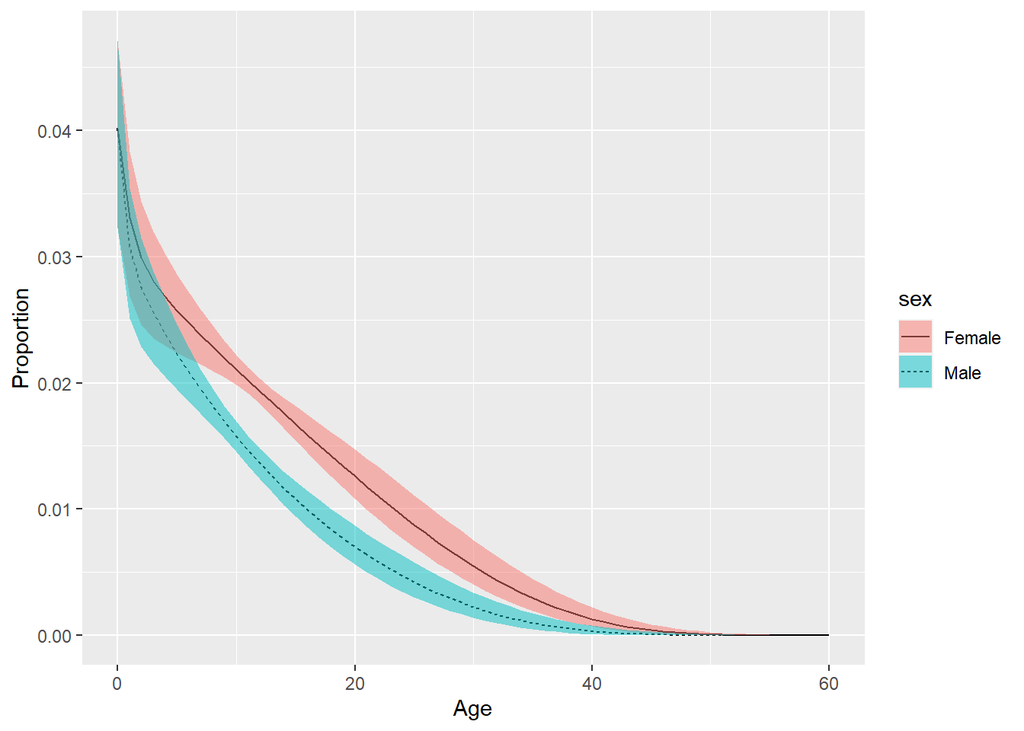

```r
#being lazy and using the ggplot code above!
#to do so re-structure results
SAFEdistNominais<-distNominais
distNominais<-as.data.frame(t(distNominais))
#To understand why this code works one needs to realize that #once like this the data structure is the same as in object
#pxMF above, so we can use what was done there
# add means and relevant quantiles
dNmean <- rowMeans(distNominais)
dNq025 <- apply(X=distNominais,MARGIN = 1,FUN=quantile,probs=0.025)
dNq975 <- apply(X=distNominais,MARGIN = 1,FUN=quantile,probs=0.975)
#now collect
distNominais$mean <- dNmean
distNominais$q025 <- dNq025
distNominais$q975 <- dNq975
#add the sex
pxFs2$sex="Female"
pxMs2$sex="Male"
#add age and sex
distNominais$sex<-pxMF$sex
distNominais$ages<-pxMF$ages
#plot
ggplot(data=distNominais, aes(x=ages, y=mean, ymin=q025, ymax=q975, fill=sex, linetype=sex)) + geom_line() +
 geom_ribbon(alpha=0.5) +
 xlab("Age") +
 ylab("Proportion")
```

## Combining components to get $\bar S$

We finally combine the above components, as described above to obtain realizations of the population-averaged baseline survival. This is then used in the simulations, combined with the results from the SCR analysis, to estimate the decrease in survival induced by exposure to oil.

```r
meanS <-numeric(B)
for(i in 1:B){
  qijs<-c(distNominais[1:61,i]*predictions[i,],distNominais[62:122,i]*predictions[i,])/sum(c(distNominais[1:61,i]*predictions[i,],distNominais[62:122,i]*predictions[i,]))
meanS[i]<-sum(pxMF[,i]*qijs)
}
```

And now we can take a look at the distribution of the estimated population-averaged survival

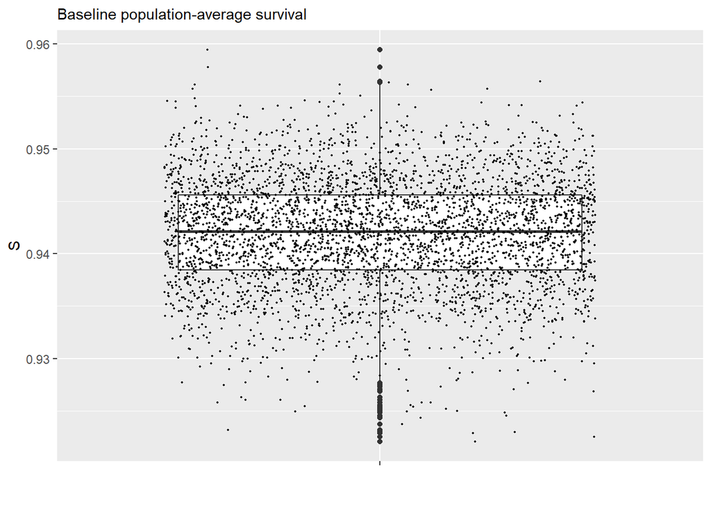

```r
#stupid tweak
meanS=data.frame(S=meanS,group=" ")
#plot
#https://www.r-graph-gallery.com/89-box-and-scatter-plot-with-ggplot2.html
meanS %>% ggplot(aes(y=S,x=group)) +
     geom_boxplot() +
     scale_fill_viridis(discrete = TRUE, alpha=0.6) +
     geom_jitter(color="black", size=0.4, alpha=0.9) +
     theme(
       legend.position="none",
       plot.title = element_text(size=11)
     ) +
     ggtitle("Baseline population-average survival") +
     xlab("")
```

Finally, we output the resulting distribution of baseline survivals, which incorporates the variance propagated through each of the 3 required components, so that they can be used in the main simulations.

```r
write.table(meanS$S,file="InputFiles/BaselineSurvival.csv",quote=FALSE,row.names = FALSE,col.names = FALSE)
```

# Comparison with survival post oil-spil

Reading in the realizations of post-oil survival obtained from the SCR study. Full details about the methods and the results are described in Glennie et al. (2021).

```r
SpostOilBB<-read.csv(file="InOutBySp/Bottlenose_dolphin_BB/PostOilSurv.csv",header=FALSE,col.names = "S")
```

We can compare the pre-spill with post-spill survival. As expected the oil had a detrimental effect on survival, which is reassuring to observe in the figure below, since these two quantities were produced from completely independent sets of data.

```r
#preparing a suitable object for plotting with ggplot
PrePosS<-data.frame(S=c(SpostOilBB$S,meanS$S),period=c(rep("post-oil",length(SpostOilBB$S)),rep("baseline",length(meanS$S))))
```

The mean of the pre-spill survival was 0.942 (95% credible intervals of 0.931 – 0.952) while the mean of the post-spill survival was 0.818 (95% credible intervals of 0.695 – 0.909), leading to an average reduction in survival post-spill of 0.868 (95% credible intervals of 0.739 – 0.965). Below we present the side-by-side comparison of pre- and post-spill survivals, where the reduction in survival is evident.

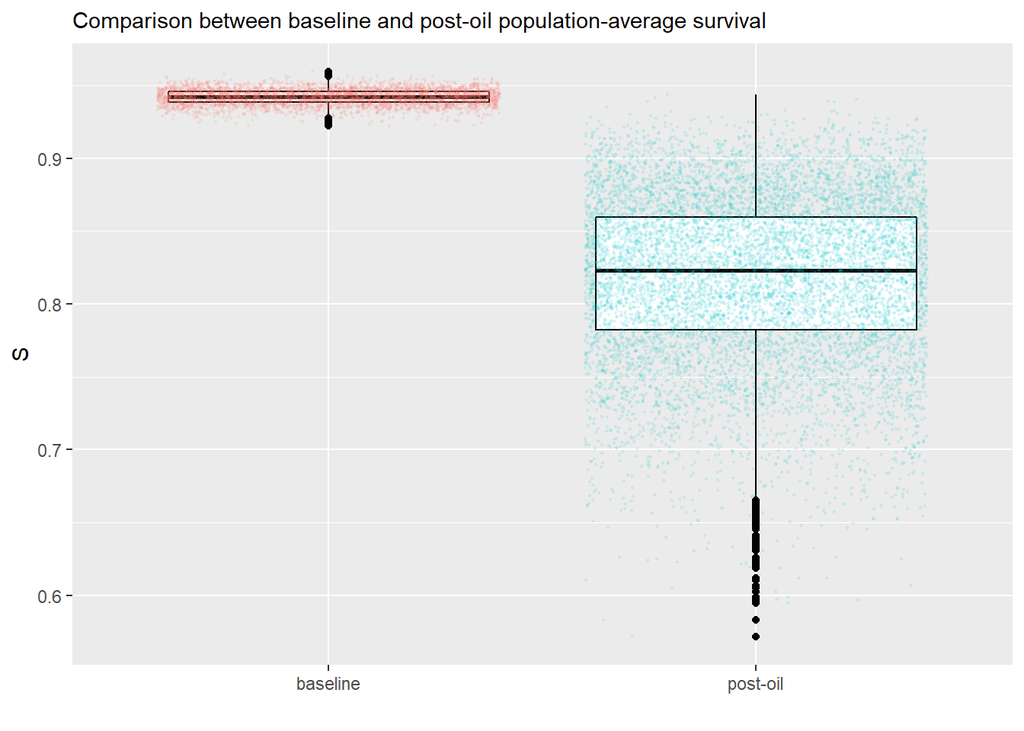

```r
#plotting it
PrePosS %>% ggplot(aes(y=S,x=period,color=period)) +
  geom_boxplot(color="black") +
  scale_fill_viridis(discrete = TRUE, alpha=0.6) +
  geom_jitter(size=0.4, alpha=0.1) +
  theme(
    legend.position="none",
    plot.title = element_text(size=11)
  ) +
  ggtitle("Comparison between baseline and post-oil population-average survival") +
  xlab("")
```

# References

Glennie, R.; Thomas, L.; Speakman, T.; Garrison, L.; Takeshita, R. & Schwacke, L. 2021. [Estimating spatially-varying density and time-varying demographics with open population spatial capture-recapture: a photo-ID case study on bottlenose dolphins in Barataria Bay, Louisana, USA](https://arxiv.org/abs/2106.09579) arXiv:2106.09579

R Core Team (2021). R: A language and environment for statistical computing. R Foundation for Statistical Computing, Vienna, Austria. URL https://www.R-project.org/.

Schwacke, L. H.; Thomas, L.; Wells, R. S.; McFee, W. E.; Hohn, A. A.; Mullin, K. D.; Zolman, E. S.; Quigley, B. M.; Rowles, T. K. & Schwacke, J. H. 2017. [Quantifying injury to common bottlenose dolphins from the Deepwater Horizon oil spill using an age-, sex- and class-structured population model](https://www.int-res.com/abstracts/esr/v33/p265-279/) *Endangered Species Research* **33**: 265-279